# Pipelines

Published

19 Mar 2023

## workflow systems

- want to *abstract* details of statistical modeling/machine learning
- benefits of abstraction
  - reduce cognitive load
  - shorter code
- costs of abstraction
  - more ‘magic’
  - learning another system
  - harder to dig down for details
  - loss of flexibility/harder to modify in ways not foreseen by designers

## R/python

Materials from [Modeling in R and Python](https://rwward.github.io/etf2021-r-py-modeling/)

- `tidymodels`: meta-package for ‘tidy’ modeling in R
- `scikit-learn`: modeling in Python

## `parsnip`

- `parsnip` package (CART → `caret` → “carrot” → `parsnip`)
- unify modeling interfaces (`lm`, `glmnet`, `randomForest`, etc etc etc)
- specify **model** (algorithm), **mode** (classification or regression), **engine** (implementation/package)
- in principle (???)

## `rsample`

- resampling, cross-validation, bootstrapping, holdout sets …
- train/test split (`initial_split()`/`training()`/`testing()`)
- cross-validation (`vfold_cv()`), bootstrap (`bootstrap`)
- blocked/grouped methods! `group_vfold_cv`, `group_bootstraps()`

## `recipes`

- feature engineering
- preprocessing (centering/scaling, imputation, dimension reduction, etc.)

## more

- `workflows`: bundle preprocessing/modeling/post-processing
- `tune`: hyperparameter tuning
- `yardstick`: assessment

## example

```r
library(tidyverse)
library(tidymodels)
library(glmnet)
source("../code/utils.R")
```

```r
historical <- (read_csv("../code/historical_baseball.csv")
    ## should these be done in the 'prep' process?
    |> mutate(across(inducted, ~fct_rev(factor(.))))
    |> filter(ab > 250)
)
data_split <- initial_split(historical, prop = 2/3, strata = inducted)
train_data <- training(data_split)
testing_data <- testing(data_split)
```

## build preprocessing recipe

- Basics here.
- Could also do PCA selection, collapse rare factor levels (`step_other()`, other filtering … (see [recipes docs](https://recipes.tidymodels.org/reference/index.html))

```r
b_recipe  <- (
    ## (? why does recipe need data?)
    recipe(inducted ~ ., data = train_data)
    ## no '-' operator in formulas
    ## could use e.g. all_numeric_predictors()
    |> step_rm("last_year")
    ## set player_id to be neither predictor or outcome
    |> update_role(player_id, new_role = "ID")
    ## center, scale, remove zero-variance variables
    |> step_center(all_numeric())
    |> step_scale(all_numeric())
    |> step_nzv(all_numeric())
)
print(b_recipe)
```

```
── Recipe ──────────────────────────────────────────────────────────────────────
```

```
── Inputs
```

```
Number of variables by role
```

```
outcome:    1
predictor: 13
ID:         1
```

```
── Operations
```

```
• Variables removed: "last_year"
```

```
• Centering for: all_numeric()
```

```
• Scaling for: all_numeric()
```

```
• Sparse, unbalanced variable filter on: all_numeric()
```

## ‘prep’ step

- Set any *data-dependent* filtering steps based on the full training data set
- Avoid data leakage

```r
b_prepped <- prep(b_recipe)
print(b_prepped)
```

```
── Recipe ──────────────────────────────────────────────────────────────────────
```

```
── Inputs
```

```
Number of variables by role
```

```
outcome:    1
predictor: 13
ID:         1
```

```
── Training information
```

```
Training data contained 1776 data points and no incomplete rows.
```

```
── Operations
```

```
• Variables removed: last_year | Trained
```

```
• Centering for: g, ab, r, h, x2b, x3b, hr, rbi, sb, cs, bb, so | Trained
```

```
• Scaling for: g, ab, r, h, x2b, x3b, hr, rbi, sb, cs, bb, so | Trained
```

```
• Sparse, unbalanced variable filter removed: <none> | Trained
```

## ‘bake’ step (and sampling)

- apply prep to new (maybe) data; sample
- can use `strata` to help balance data, and to avoid data leakage

```r
b_prepped |> bake(train_data) |> rsample::vfold_cv(v=10)
```

```
#  10-fold cross-validation
# A tibble: 10 × 2
   splits             id
   <list>             <chr>
 1 <split [1598/178]> Fold01
 2 <split [1598/178]> Fold02
 3 <split [1598/178]> Fold03
 4 <split [1598/178]> Fold04
 5 <split [1598/178]> Fold05
 6 <split [1598/178]> Fold06
 7 <split [1599/177]> Fold07
 8 <split [1599/177]> Fold08
 9 <split [1599/177]> Fold09
10 <split [1599/177]> Fold10
```

## logistic regression

```r
lrc_mod <- (
    logistic_reg(mode = "classification",
                 penalty = tune(),
                 mixture = tune())
    |> set_engine(engine = "glmnet")
)
print(lrc_mod)
```

```
Logistic Regression Model Specification (classification)

Main Arguments:
  penalty = tune()
  mixture = tune()

Computational engine: glmnet
```

## digression: experimental design

- sample over a multidimensional space?
- grids (easy, inflexible)
- random samples (too clustered)
- **space-filling**
  - Latin hypercube
  - *Sobol sequences*

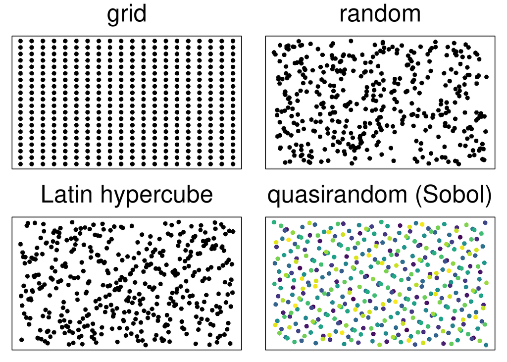

Set up parallel processing (`foreach` package)

```r
doParallel::registerDoParallel(cores = 4)
```

```r
system.time(tt <- tune_grid(
    grid = 100,
    object = lrc_mod,
    preprocessor = b_prepped,
    resamples = vfold_cv(train_data),
    ## decided to use deviance rather than accuracy to train
    metrics   = metric_set(mn_log_loss)
    ## , control = control_grid(verbose = TRUE)
))
```

```
   user  system elapsed
325.105   0.948  95.494
```

```r
saveRDS(tt, "tune_grid.rds")
```

[obligatory xkcd](https://xkcd.com/303/)

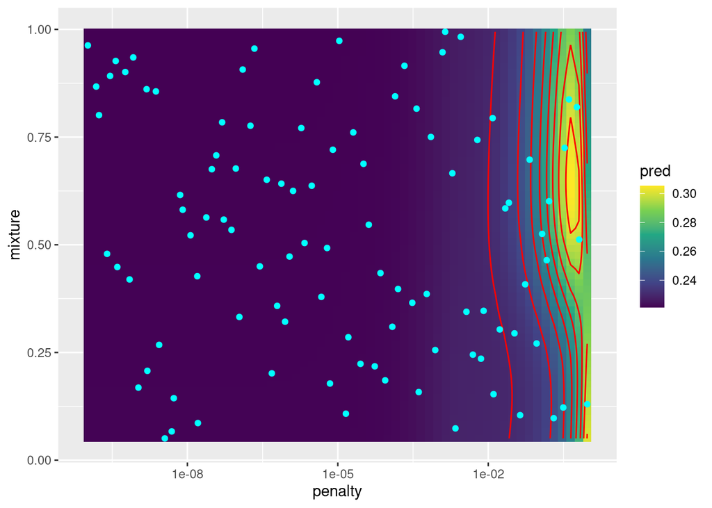

```r
## tt <- readRDS("tune_grid.rds")
cc <- collect_metrics(tt)
## not actually a good design for this case ...
gg0 <- ggplot(cc, aes(penalty, mixture)) + geom_point() + scale_x_log10()
## make regular grid for plotting
dd <- with(cc,
           expand.grid(penalty = sfun(penalty, TRUE),
                       mixture = sfun(mixture))
           )
m1 <- mgcv::gam(mean ~ te(penalty, mixture), data = cc)
dd$pred <- as.numeric(predict(m1, newdata = dd))
gg1 <- ggplot(dd, aes(penalty, mixture)) +
    scale_fill_viridis_c() +
    geom_tile(aes(fill = pred)) +
    geom_contour(aes(z = pred), colour = "red") +
    scale_x_log10() +
    geom_point(data = cc, colour = "cyan")
print(gg1)
```

## sanity check

```r
system.time(
    c1 <- cv.glmnet(y = train_data$inducted,
                x = model.matrix(~ . - inducted -player_id, train_data),
                family = binomial(),
                relax = TRUE,
                data = train_data,
                parallel = TRUE)
)
```

```
   user  system elapsed
  7.810   0.371   3.028
```

(Why so much faster?? Warm start etc. …)

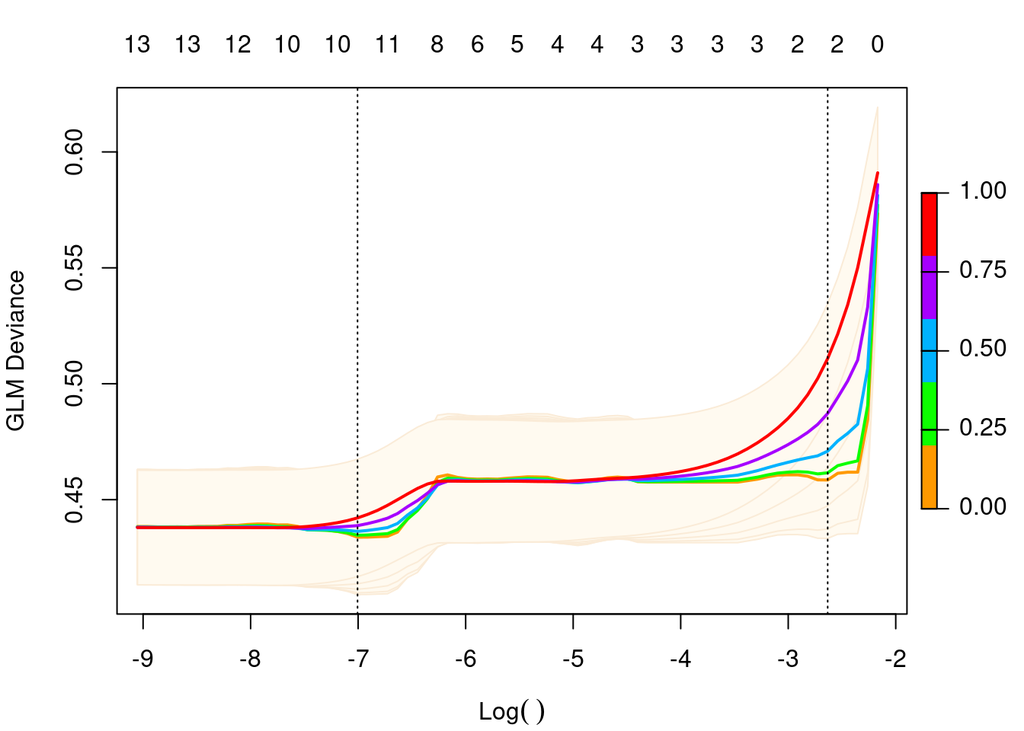

```r
plot(c1)
```

## tangent: testing the `mn_log_loss` rule

```r
x <- factor(1:4)
xmat <- diag(4)
p <- matrix(rgamma(16, shape = 1, scale = 1), 4, 4)
p <- sweep(p, MARGIN=1, STATS=rowSums(p), FUN ="/")
stopifnot(all.equal(rowSums(p), rep(1,4)))
yardstick::mn_log_loss_vec(truth = x, estimate = p)
```

```
[1] 1.533146
```

```r
-1 * mean(sapply(1:nrow(p),
                 \(i) dmultinom(x = xmat[i,], size = 1, prob = p[i,], log = TRUE)))
```

```
[1] 1.533146
```

## conclusions?

More to do:

- find best model
- show variable importance?
- predictions (with confidence intervals?)
- partial dependence profiles?

```r
show_best(tt)
model_profile(select_by_one_std_err(tt, "penalty"))
```

## Python

initial

```python
import numpy as np
import pandas as pd
from sklearn.model_selection import train_test_split
historical = pd.read_csv("../code/historical_baseball.csv").query("ab>250")

## index var
historical_pidindex = historical.set_index('player_id')
X = historical_pidindex.drop(['inducted', 'last_year'], axis = 1)
y = historical_pidindex.inducted
X_train, X_test, y_train, y_test = train_test_split(X, y, random_state=0, test_size = 1/3)
```

```python
from sklearn import preprocessing
from sklearn.linear_model import LogisticRegression
from sklearn.linear_model import LogisticRegressionCV
from sklearn.model_selection import train_test_split
from sklearn.pipeline import make_pipeline
from sklearn.preprocessing import StandardScaler
from sklearn.feature_selection import VarianceThreshold
```

```python
pipe_scale_lr_lasso = make_pipeline(StandardScaler(),
                                    VarianceThreshold(),
                                    LogisticRegressionCV(Cs = 10,
                                                         penalty = "elasticnet",
                                                         solver = "saga",
                                                         scoring = "neg_log_loss",
                                                         l1_ratios = np.linspace(0, 1, 6),
                                                         cv = 10,
                                                         max_iter = 2000,
                                                         n_jobs = 4))
```

```python
pipe_scale_lr_lasso.fit(X_train, y_train)  # apply scaling on training data
```

```
Pipeline(steps=[('standardscaler', StandardScaler()),
                ('variancethreshold', VarianceThreshold()),
                ('logisticregressioncv',
                 LogisticRegressionCV(cv=10,
                                      l1_ratios=array([0. , 0.2, 0.4, 0.6, 0.8, 1. ]),
                                      max_iter=2000, n_jobs=4,
                                      penalty='elasticnet',
                                      scoring='neg_log_loss', solver='saga'))])
```

```python
coefs = pipe_scale_lr_lasso.named_steps['logisticregressioncv'].coef_
coef_summary = pd.DataFrame(coefs.transpose(), columns = ['coefs'], index = X_train.columns)
print(coef_summary)
```

```
        coefs
g    2.408525
ab  -4.755643
r    1.836058
h    1.994425
x2b -0.384204
x3b -0.024015
hr   0.030775
rbi  0.653011
sb   0.039867
cs  -0.246170
bb  -0.501629
so  -0.005358
```

```python
pipe_scale_lr_lasso.score(X_test, y_test)
```

```
-0.220230816892793
```

**to do**:

- selected penalty, mixture parameters? (expect v. unstable)
- predictions?
- uncertainty of predictions?